# L11 - Hypothesis Testing

## Lecture Goals

- Understand fundamentals of hypothesis testing
  - Formulating hypotheses
  - Calculating test statistics
  - Interpreting P-values
- Perform randomization tests for comparisons
- Readings
  - [ISRS](https://www.openintro.org/download.php?file=isrs1_tablet&referrer=/stat/textbook.php): ch. 2.1-2.4

## Hypothesis Testing

- **Hypothesis**: claim about population, e.g.
  - Proposal will pass popular vote
  - Women are paid less than men
  - Drug X is more effective than drug Y
- **Hypothesis testing**: procedure for determining validity of hypothesis *based on sample evidence*

## Test Statistic

- Associate hypothesis with a **test statistic**, i.e. quantity calculated from data
- E.g. Interested in whether proposal will pass popular vote
  - Test statistic is *proportion* of favourable votes
- To assess hypothesis, need to know *behaviour* of test statistic
  - Compare statistic to its *sampling distribution* under hypothesis

## Null & Alternative Hypotheses

- For every claim there are two competing hypotheses: the claim and its opposite
  - E.g. proposal will pass vs it will *not* pass
- **Null Hypothesis** (\(H_0\)): *Reference* hypothesis, representing baseline or status quo
  - Used for deriving test's sampling distribution
- **Alternative Hypothesis** (\(H_A\) or \(H_1\)): Opposite of \(H_0\)
  - Almost always corresponds to claim of interest

## Data Tribunal

- Hypothesis testing resembles legal trial
  - *Presume* innocence
  - Present *evidence*; if it is inconsistent with innocence, declare guilty
  - *Burden of proof is on showing guilt*
- Similarly in a hypothesis test
  - *Presume* null hypothesis (\(H_0\)) is true
  - Collect data; if *test statistic* is inconsistent with \(H_0\), reject it and adopt \(H_A\)
  - *Burden of proof is on alternative*

## Example

- Out of SRS of 100 individuals, 59 are in favor of proposal
  - Want to know if proposal will pass referendum
- \(H_0: p \leq .5\) vs \(H_A: p>.5\)
  - \(p\) is (population) proportion in favor
- Test statistic is **sample** proportion \(\hat{p} = .59\)
  - Compare to sampling distribution under borderline value (\(p=.5\))

## Example

- Approximate sampling distribution under \(H_0\) (\(p=.5\)) by simulating 1,000 test statistic values

```r
sim = tibble( iter = 1:1000,
              value = replicate( 1000,
        sample( 0:1, 100, replace = TRUE ) %>% mean() ) )
sim
## # A tibble: 1,000 x 2
##     iter value
##    <int> <dbl>
##  1     1  0.47
##  2     2  0.5
##  3     3  0.48
##  4     4  0.44
##  5     5  0.46
##  6     6  0.55
##  7     7  0.51
##  8     8  0.48
##  9     9  0.52
## 10    10  0.52
## # ... with 990 more rows
```

## Example

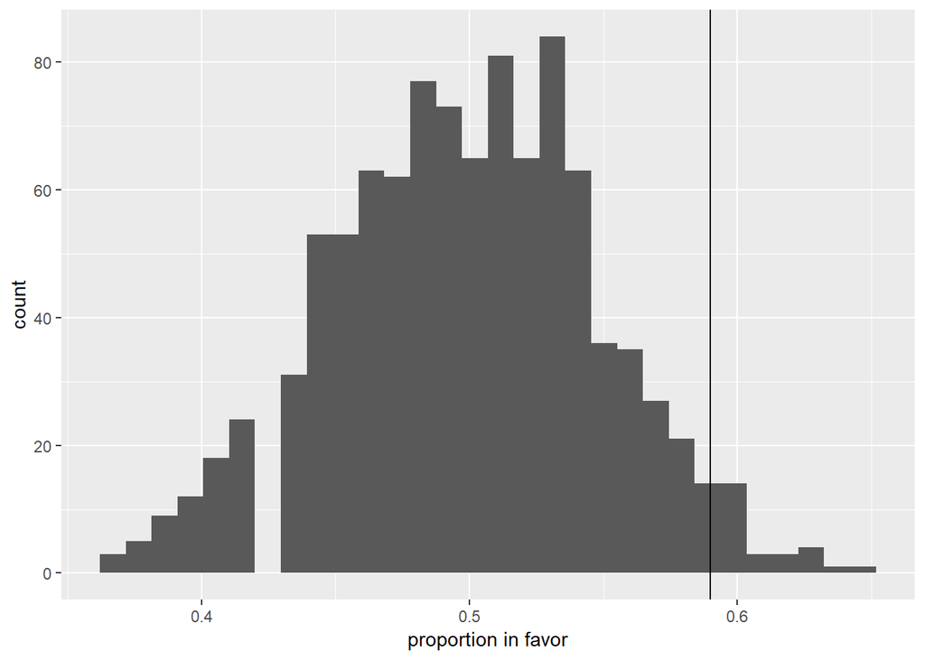

## P-value

- **P-value**: probability that sampling distribution under \(H_0\) gives values *at least as favorable* to \(H_A\) as observed statistic
  - Lower P-value \(\rightarrow\) data less *consistent* with \(H_0\)

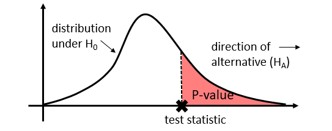

- Compare P-value to *predetermined* cut-off, called **significance level** (\(\alpha\))
  - "Typical" value of \(\alpha = .05 = 1/20\)
  - If P-value \(< \alpha \rightarrow\) reject \(H_0\) & accept \(H_A\)